# Welcome to DS 400 Introduction to Data Science

Introductions, syllabus, course overview, etc.

[figure not shown]

Lectures, labs and HW will all be taught and completed using Jupyter notebooks. There will be much more information on Jupyter Notebooks in future labs and HW.

# Chapter 1: Data Science

## What is Data Science

Data science is the intersection of programming, statistics, and domain expertise. This definition has been attributed to Drew Conway<sup>1</sup>

[figure not shown]

http://drewconway.com/zia/2013/3/26/the-data-science-venn-diagram

Hacking Skills = FSO (figuring sh!t out)  
Hacking Skills != programming  
**You do not need to be a software programmer to be a data scientest. But you must be resouceful and have perseverance**

[figure not shown]

## Program languages of data scientists

There are many types of progamming languages data scientsts use. There is no right answer and the language you use may depend a lot on the problem you are solving. (*Xbox or PS? Cannon or Nikon? Dewalt or Milwalkee?*) However, Python is winning the data science programming wars and is the programming language we will focus on the most. Below are the logos for Python, R, and Julia.

[figure not shown]

## Data Science Lifecycle

[figure not shown]

Figure credit<sup>2</sup>  
https://www.edureka.co/blog/what-is-data-science/

Data exploration is an essential part of data science. This is where we perform EDA (exploratory data analysis), visualize the data, and perform discriptive statistics.

Prediction phase is modeling the data though machine learning.

Finally, we infere what we can from the models and communicate the results.

# Lets do some data science!

This document is a Jupyter Notebook. We will be using Jupyter Notebooks throughout the program and you will quickly become familiar with them. For now, lets just run the cells. There are a few ways you can run a cell. My perfered method is using keyboard strokes *shift + enter* will run a cell. Or you can click on the the play button in the top left of the cell which looks like this:

[figure not shown]

Other kyboard shortcuts can be found by pressing *Esc H*. Or from the Help drop down menu.

```python
# Stuff that will appear at the top of notebooks;
# You don't have to understand how this works.
# Do not change anything in this cell.  Just run it for now.

from datascience import *
import numpy as np
%matplotlib inline
import matplotlib.pyplot as plots
plots.style.use('fivethirtyeight')
import warnings
warnings.simplefilter(action="ignore", category=FutureWarning)

from urllib.request import urlopen
import re
def read_url(url):
    return re.sub('\\s+', ' ', urlopen(url).read().decode())
```

```python
# Read two books, fast!

huck_finn_url = 'https://www.inferentialthinking.com/data/huck_finn.txt'
huck_finn_text = read_url(huck_finn_url)
huck_finn_chapters = huck_finn_text.split('CHAPTER ')[44:]

little_women_url = 'https://www.inferentialthinking.com/data/little_women.txt'
little_women_text = read_url(little_women_url)
little_women_chapters = little_women_text.split('CHAPTER ')[1:]
```

```python
huck_finn_chapters
```

```
['I. YOU don\'t know about me without you have read a book by the name of The Adventures of Tom Sawyer; but that ain\'t no matter. That book was made by Mr. Mark Twain, and he told the truth, mainly. There was things which he stretched, but mainly he told the truth. That is nothing. I never seen any…
 'II. WE went tiptoeing along a path amongst the trees back towards the end of the widow\'s garden, stooping down so as the branches wouldn\'t scrape our heads. When we was passing by the kitchen I fell over a root and made a noise. We scrouched down and laid still. Miss Watson\'s big nigger, named …
 'III. WELL, I got a good going-over in the morning from old Miss Watson on account of my clothes; but the widow she didn\'t scold, but only cleaned off the grease and clay, and looked so sorry that I thought I would behave awhile if I could. Then Miss Watson she took me in the closet and prayed, bu…
 'IV. WELL, three or four months run along, and it was well into the winter now. I had been to school most all the time and could spell and read and write just a little, and could say the multiplication table up to six times seven is thirty-five, and I don\'t reckon I could ever get any further than…
 'V. I had shut the door to. Then I turned around and there he was. I used to be scared of him all the time, he tanned me so much. I reckoned I was scared now, too; but in a minute I see I was mistaken--that is, after the first jolt, as you may say, when my breath sort of hitched, he being so unexpe…
 'VI. WELL, pretty soon the old man was up and around again, and then he went for Judge Thatcher in the courts to make him give up that money, and he went for me, too, for not stopping school. He catched me a couple of times and thrashed me, but I went to school just the same, and dodged him or outr…
 'VII. "GIT up! What you \'bout?" I opened my eyes and looked around, trying to make out where I was. It was after sun-up, and I had been sound asleep. Pap was standing over me looking sour and sick, too. He says: "What you doin\' with this gun?" I judged he didn\'t know nothing about what he had be…
 'VIII. THE sun was up so high when I waked that I judged it was after eight o\'clock. I laid there in the grass and the cool shade thinking about things, and feeling rested and ruther comfortable and satisfied. I could see the sun out at one or two holes, but mostly it was big trees all about, and …
 'IX. I wanted to go and look at a place right about the middle of the island that I\'d found when I was exploring; so we started and soon got to it, because the island was only three miles long and a quarter of a mile wide. This place was a tolerable long, steep hill or ridge about forty foot high.…
 'X. AFTER breakfast I wanted to talk about the dead man and guess out how he come to be killed, but Jim didn\'t want to. He said it would fetch bad luck; and besides, he said, he might come and ha\'nt us; he said a man that warn\'t buried was more likely to go a-ha\'nting around than one that was p…
 'XI. "COME in," says the woman, and I did. She says: "Take a cheer." I done it. She looked me all over with her little shiny eyes, and says: "What might your name be?" "Sarah Williams." "Where \'bouts do you live? In this neighborhood?\' "No\'m. In Hookerville, seven mile below. I\'ve walked all th…
 'XII. IT must a been close on to one o\'clock when we got below the island at last, and the raft did seem to go mighty slow. If a boat was to come along we was going to take to the canoe and break for the Illinois shore; and it was well a boat didn\'t come, for we hadn\'t ever thought to put the gu…
 'XIII. WELL, I catched my breath and most fainted. Shut up on a wreck with such a gang as that! But it warn\'t no time to be sentimentering. We\'d _got_ to find that boat now--had to have it for ourselves. So we went a-quaking and shaking down the stabboard side, and slow work it was, too--seemed a…
 'XIV. BY and by, when we got up, we turned over the truck the gang had stole off of the wreck, and found boots, and blankets, and clothes, and all sorts of other things, and a lot of books, and a spyglass, and three boxes of seegars. We hadn\'t ever been this rich before in neither of our lives. Th…
 'XV. WE judged that three nights more would fetch us to Cairo, at the bottom of Illinois, where the Ohio River comes in, and that was what we was after. We would sell the raft and get on a steamboat and go way up the Ohio amongst the free States, and then be out of trouble. Well, the second night a…
 'XVI. WE slept most all day, and started out at night, a little ways behind a monstrous long raft that was as long going by as a procession. She had four long sweeps at each end, so we judged she carried as many as thirty men, likely. She had five big wigwams aboard, wide apart, and an open camp fi…
 'XVII. IN about a minute somebody spoke out of a window without putting his head out, and says: "Be done, boys! Who\'s there?" I says: "It\'s me." "Who\'s me?" "George Jackson, sir." "What do you want?" "I don\'t want nothing, sir. I only want to go along by, but the dogs won\'t let me." "What are …
 'XVIII. COL. Grangerford was a gentleman, you see. He was a gentleman all over; and so was his family. He was well born, as the saying is, and that\'s worth as much in a man as it is in a horse, so the Widow Douglas said, and nobody ever denied that she was of the first aristocracy in our town; and…
```

[output cut: 25 more lines]

```python
Table().with_column('Chapters', huck_finn_chapters)
```

| Chapters |
| --- |
| I. YOU don't know about me without you have read a book ... |
| II. WE went tiptoeing along a path amongst the trees bac ... |
| III. WELL, I got a good going-over in the morning from o ... |
| IV. WELL, three or four months run along, and it was wel ... |
| V. I had shut the door to. Then I turned around and ther ... |
| VI. WELL, pretty soon the old man was up and around agai ... |
| VII. "GIT up! What you 'bout?" I opened my eyes and look ... |
| VIII. THE sun was up so high when I waked that I judged ... |
| IX. I wanted to go and look at a place right about the m ... |
| X. AFTER breakfast I wanted to talk about the dead man a ... |

... (33 rows omitted)

```python
np.char.count(huck_finn_chapters, 'Tom')
```

```
array([ 6, 24,  5,  0,  0,  0,  2,  2,  0,  0,  2,  3,  1,  0,  0,  0,  3,
        5,  0,  0,  0,  0,  0,  0,  0,  0,  0,  1,  0,  0,  1,  4, 19, 15,
       14, 18,  9, 32, 11, 11,  8, 30,  6])
```

```python
np.char.count(huck_finn_chapters, 'Jim')
```

```
array([ 0, 16,  0,  8,  0,  0,  0, 22, 11, 19,  4, 20,  9,  6, 16, 28,  0,
       10, 13, 18,  1,  0,  9,  5,  0,  0,  0,  1,  3,  5, 17,  0,  5, 17,
       18, 23,  4, 27, 10, 13,  0, 12,  6])
```

```python
counts = Table().with_columns([
    'Tom', np.char.count(huck_finn_chapters, 'Tom'),
    'Jim', np.char.count(huck_finn_chapters, 'Jim'),
    'Huck', np.char.count(huck_finn_chapters, 'Huck'),
])
counts
```

| Tom | Jim | Huck |
| --- | --- | --- |
| 6 | 0 | 3 |
| 24 | 16 | 2 |
| 5 | 0 | 2 |
| 0 | 8 | 1 |
| 0 | 0 | 0 |
| 0 | 0 | 2 |
| 2 | 0 | 0 |
| 2 | 22 | 5 |
| 0 | 11 | 1 |
| 0 | 19 | 0 |

... (33 rows omitted)

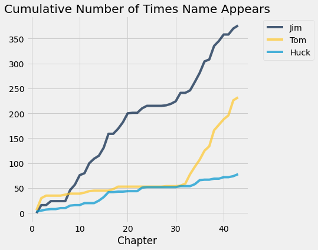

```python
# Count how many times the names Jim, Tom, and Huck appear in each chapter

counts = Table().with_columns([
        'Jim', np.char.count(huck_finn_chapters, 'Jim'),
        'Tom', np.char.count(huck_finn_chapters, 'Tom'),
        'Huck', np.char.count(huck_finn_chapters, 'Huck')
    ])

# Plot the cumulative counts:
# how many times in Chapter 1, how many times in Chapters 1 and 2, and so on.

cum_counts = counts.cumsum().with_column('Chapter', np.arange(1, 44, 1))
cum_counts.plot(column_for_xticks=3)
plots.title('Cumulative Number of Times Name Appears');
```

```python
# The chapters of Little Women

Table().with_column('Chapters', little_women_chapters)
```

| Chapters |
| --- |
| ONE PLAYING PILGRIMS "Christmas won't be Christmas witho ... |
| TWO A MERRY CHRISTMAS Jo was the first to wake in the gr ... |
| THREE THE LAURENCE BOY "Jo! Jo! Where are you?" cried Me ... |
| FOUR BURDENS "Oh, dear, how hard it does seem to take up ... |
| FIVE BEING NEIGHBORLY "What in the world are you going t ... |
| SIX BETH FINDS THE PALACE BEAUTIFUL The big house did pr ... |
| SEVEN AMY'S VALLEY OF HUMILIATION "That boy is a perfect ... |
| EIGHT JO MEETS APOLLYON "Girls, where are you going?" as ... |
| NINE MEG GOES TO VANITY FAIR "I do think it was the most ... |
| TEN THE P.C. AND P.O. As spring came on, a new set of am ... |

... (37 rows omitted)

```python
# Counts of names in the chapters of Little Women

people = ['Amy', 'Beth', 'Jo', 'Laurie', 'Meg']
people_counts = {pp: np.char.count(little_women_chapters, pp) for pp in people}

counts = Table().with_columns([
        'Amy', people_counts['Amy'],
        'Beth', people_counts['Beth'],
        'Jo', people_counts['Jo'],
        'Laurie', people_counts['Laurie'],
        'Meg', people_counts['Meg']
    ])
```

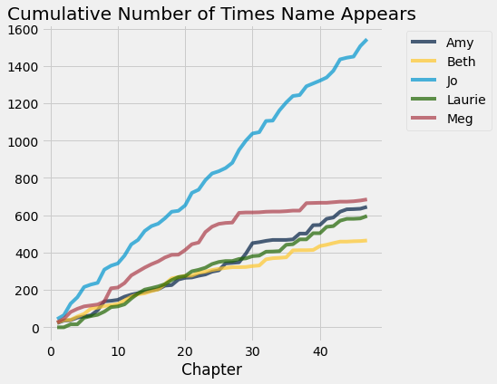

```python
# Plot the cumulative counts
cum_counts = counts.cumsum().with_column('Chapter', np.arange(1, 48, 1))
cum_counts.plot(column_for_xticks=5)
plots.title('Cumulative Number of Times Name Appears');
```

Laurie is a young man who marries one of the girls in the end. See if you can use the plots to guess which one.

```python
# In each chapter, count the number of all characters;
# call this the "length" of the chapter.
# Also count the number of periods.

chars_periods_hf = Table().with_columns([
        'HF Chapter Length', [len(s) for s in huck_finn_chapters],
        'Number of Periods', np.char.count(huck_finn_chapters, '.')
    ])
chars_periods_lw = Table().with_columns([
        'LW Chapter Length', [len(s) for s in little_women_chapters],
        'Number of Periods', np.char.count(little_women_chapters, '.')
    ])
```

```python
# The counts for Huckleberry Finn
chars_periods_hf
```

| HF Chapter Length | Number of Periods |
| --- | --- |
| 7026 | 66 |
| 11982 | 117 |
| 8529 | 72 |
| 6799 | 84 |
| 8166 | 91 |
| 14550 | 125 |
| 13218 | 127 |
| 22208 | 249 |
| 8081 | 71 |
| 7036 | 70 |

... (33 rows omitted)

```python
# The counts for Little Women
chars_periods_lw
```

| LW Chapter Length | Number of Periods |
| --- | --- |
| 21759 | 189 |
| 22148 | 188 |
| 20558 | 231 |
| 25526 | 195 |
| 23395 | 255 |
| 14622 | 140 |
| 14431 | 131 |
| 22476 | 214 |
| 33767 | 337 |
| 18508 | 185 |

... (37 rows omitted)

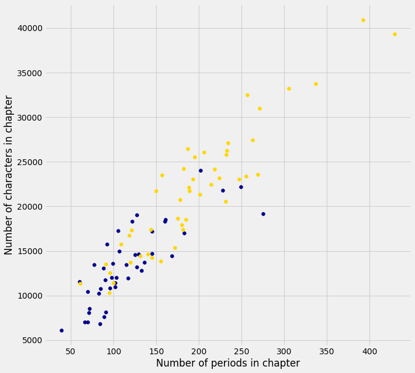

```python
plots.figure(figsize=(10,10))
plots.scatter(chars_periods_hf[1], chars_periods_hf[0], color='darkblue')
plots.scatter(chars_periods_lw[1], chars_periods_lw[0], color='gold')
plots.xlabel('Number of periods in chapter')
plots.ylabel('Number of characters in chapter');
```

Which book tends to have the longer chapters?

# Chapter 2: Causality and Experiments

- Is chocolate good for you?
- Do Nicholas Cage movie releases cause pool drowings?
- Does association imply causation?
- Association if there is any relation between treatment and outcome.
- Causation if the treatment cause the outcome to occur.

[figure not shown]

Figure credit comes from Tyler Vigen's website which is worth a visit for a good laugh<sup>3</sup>  
http://www.tylervigen.com/spurious-correlations

- Obervational study is where scientists oberve without experimenting on the outcome.
- They may observe individuals, subjects, participants on a treatment or factor, and observe the resluts or outcome measured on the individual.
- Is there any relation between chocolate consuption and heart disease? This question asks if there is an association - any relation or link.
- Does chocolate consuption lead to a decreast in heart disease? This is harder to answer and asks if there is a causation.

### John Snow and the Broad Street Pump

- In 1854 there was a cholera outbreak in Soho district of London.
- John Snow was a local doctor who had been tracing cholera outbreaks for sometime.
- He mapped the location of the outbreak in 1854.

[figure not shown]

## John Snow's Grand Experiment

After find in the source of the Soho cholera outbreak, Jonh Snow set to find the source of other outbreaks in London.

[figure not shown]

- John Snow established an obervational experiment.
- Who did he observe?
- What was the treatment or factor?
- What were the observed results?

## Confounding variables

- Coffee and lung cancer experiments in 1960s

## Randomization

- Control and treatment groups
- Did John Snow's Grand Experiment have control and treatment groups?
- Single blind experiments
- Double blind experiments
- Triple blind experiments
- PROGRESA welfare in Mexico in 1990's
- Elementry school enrollment for boys increased from 73% to 77% while girls enrollment increased from 67% to 75%

## Terminology

- observational study
- treatment
- outcome
- association
- causal association
- causality
- comparison
- treatment group
- control group
- confounding
- randomization
- blind
- placebo